# HW3: Tidy Data

Jenna Loesberg

10/6/2019

[Instructions are found here](https://stat545.stat.ubc.ca/evaluation/hw04/hw04/)

### Exercise 1:

#### Univariate Option 1:

#### 1.1. Make a tibble with one row per year, and columns for life expectancy for two or more countries.

What it looks like before:

```r
gapminder %>%
  datatable()
```

|  | country | continent | year | lifeExp | pop | gdpPercap |
| --- | --- | --- | --- | --- | --- | --- |
| 1 | Afghanistan | Asia | 1952 | 28.801 | 8425333 | 779.4453145 |
| 2 | Afghanistan | Asia | 1957 | 30.332 | 9240934 | 820.8530296 |
| 3 | Afghanistan | Asia | 1962 | 31.997 | 10267083 | 853.10071 |
| 4 | Afghanistan | Asia | 1967 | 34.02 | 11537966 | 836.1971382 |
| 5 | Afghanistan | Asia | 1972 | 36.088 | 13079460 | 739.9811058 |
| 6 | Afghanistan | Asia | 1977 | 38.438 | 14880372 | 786.11336 |
| 7 | Afghanistan | Asia | 1982 | 39.854 | 12881816 | 978.0114388 |
| 8 | Afghanistan | Asia | 1987 | 40.822 | 13867957 | 852.3959448 |
| 9 | Afghanistan | Asia | 1992 | 41.674 | 16317921 | 649.3413952 |
| 10 | Afghanistan | Asia | 1997 | 41.763 | 22227415 | 635.341351 |

[output cut: 1694 more lines]

Using pivot_wider to get table where each year is a new entry, and include life expectancy for 2 countries:

```r
gapminder2 <-
  gapminder %>%
  filter(country == "Australia"| country ==  "Canada") %>%
  select(country, year, lifeExp) %>%
  pivot_wider(id_cols = year,
              names_from = country,
              values_from = lifeExp)

datatable(gapminder2)
```

|  | year | Australia | Canada |
| --- | --- | --- | --- |
| 1 | 1952 | 69.12 | 68.75 |
| 2 | 1957 | 70.33 | 69.96 |
| 3 | 1962 | 70.93 | 71.3 |
| 4 | 1967 | 71.1 | 72.13 |
| 5 | 1972 | 71.93 | 72.88 |
| 6 | 1977 | 73.49 | 74.21 |
| 7 | 1982 | 74.74 | 75.76 |
| 8 | 1987 | 76.32 | 76.86 |
| 9 | 1992 | 77.56 | 77.95 |
| 10 | 1997 | 78.83 | 78.61 |

[output cut: 2 more lines]

#### 1.2. Take advantage of this new data shape to scatterplot life expectancy for one country against that of another.

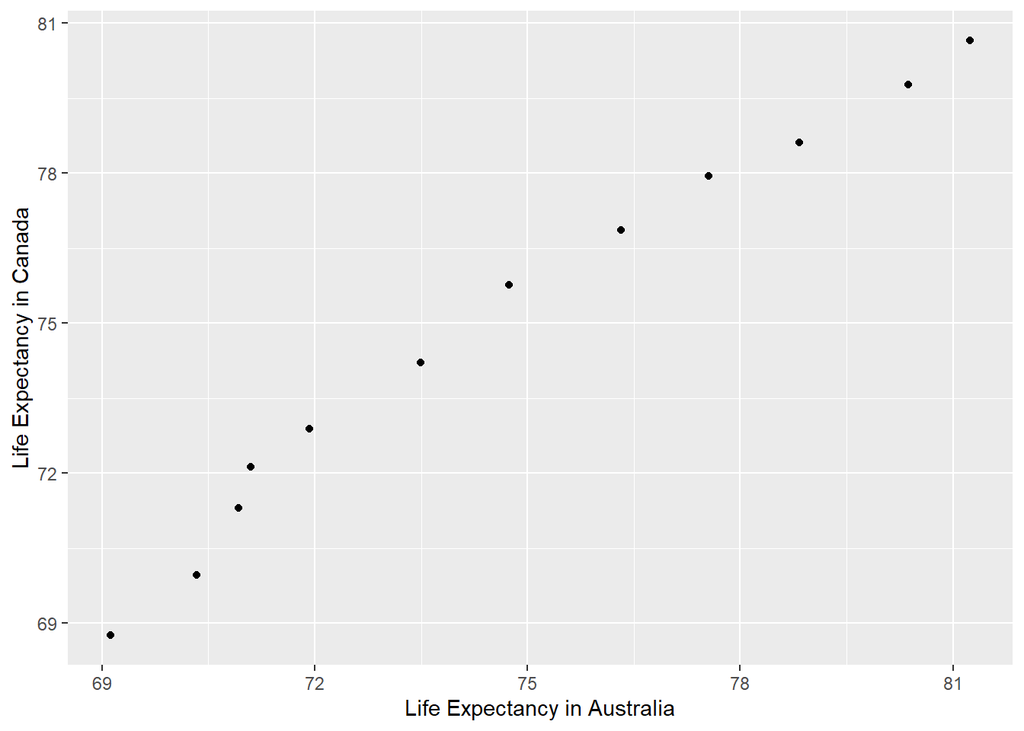

```r
gapminder2 %>%
  ggplot() +
  geom_point(aes(Australia, Canada))+
  xlab("Life Expectancy in Australia") +
  ylab("Life Expectancy in Canada")
```

#### 1.3. Re-lengthen the data.

```r
gapminder2 %>%
   pivot_longer(cols = c(Australia, Canada),
               names_to = "country",
               values_to = "lifeExp") %>%
  arrange(country) %>%
  datatable()
```

|  | year | country | lifeExp |
| --- | --- | --- | --- |
| 1 | 1952 | Australia | 69.12 |
| 2 | 1957 | Australia | 70.33 |
| 3 | 1962 | Australia | 70.93 |
| 4 | 1967 | Australia | 71.1 |
| 5 | 1972 | Australia | 71.93 |
| 6 | 1977 | Australia | 73.49 |
| 7 | 1982 | Australia | 74.74 |
| 8 | 1987 | Australia | 76.32 |
| 9 | 1992 | Australia | 77.56 |
| 10 | 1997 | Australia | 78.83 |

[output cut: 14 more lines]

### Exercise 2

#### Multivariate Option 1

#### 2.1. Make a tibble with one row per year, and columns for life expectancy and GDP per capita (or two other numeric variables) for two or more countries.

```r
gapminder3 <-
  gapminder %>%
  filter(country == "Australia"| country ==  "Canada") %>%
  select(country, year, lifeExp, gdpPercap) %>%
  pivot_wider(id_cols = year,
              names_from = country,
              values_from = c(lifeExp, gdpPercap))
datatable(gapminder3)
```

|  | year | lifeExp_Australia | lifeExp_Canada | gdpPercap_Australia | gdpPercap_Canada |
| --- | --- | --- | --- | --- | --- |
| 1 | 1952 | 69.12 | 68.75 | 10039.59564 | 11367.16112 |
| 2 | 1957 | 70.33 | 69.96 | 10949.64959 | 12489.95006 |
| 3 | 1962 | 70.93 | 71.3 | 12217.22686 | 13462.48555 |
| 4 | 1967 | 71.1 | 72.13 | 14526.12465 | 16076.58803 |
| 5 | 1972 | 71.93 | 72.88 | 16788.62948 | 18970.57086 |
| 6 | 1977 | 73.49 | 74.21 | 18334.19751 | 22090.88306 |
| 7 | 1982 | 74.74 | 75.76 | 19477.00928 | 22898.79214 |
| 8 | 1987 | 76.32 | 76.86 | 21888.88903 | 26626.51503 |
| 9 | 1992 | 77.56 | 77.95 | 23424.76683 | 26342.88426 |
| 10 | 1997 | 78.83 | 78.61 | 26997.93657 | 28954.92589 |

[output cut: 2 more lines]

#### 2.2. Re-lengthen the data.

```r
gapminder3 %>%
  pivot_longer(cols = -year,
               names_to = c(".value", "country"),
               names_sep = "_") %>%
  arrange(country) %>%
  datatable()
```

|  | year | country | lifeExp | gdpPercap |
| --- | --- | --- | --- | --- |
| 1 | 1952 | Australia | 69.12 | 10039.59564 |
| 2 | 1957 | Australia | 70.33 | 10949.64959 |
| 3 | 1962 | Australia | 70.93 | 12217.22686 |
| 4 | 1967 | Australia | 71.1 | 14526.12465 |
| 5 | 1972 | Australia | 71.93 | 16788.62948 |
| 6 | 1977 | Australia | 73.49 | 18334.19751 |
| 7 | 1982 | Australia | 74.74 | 19477.00928 |
| 8 | 1987 | Australia | 76.32 | 21888.88903 |
| 9 | 1992 | Australia | 77.56 | 23424.76683 |
| 10 | 1997 | Australia | 78.83 | 26997.93657 |

[output cut: 14 more lines]

### Exercise 3

reading in data

```r
guest <- read_csv("https://raw.githubusercontent.com/STAT545-UBC/Classroom/master/data/wedding/attend.csv")
email <- read_csv("https://raw.githubusercontent.com/STAT545-UBC/Classroom/master/data/wedding/emails.csv")
```

#### 3.1

For each guest in the guestlist (guest tibble), add a column for email address, which can be found in the email tibble.

Need to rearrange the email file so it matches the guest file:

```r
email2 <-
  email %>%
  separate_rows(guest, sep = ", ") %>%
  rename(name = guest)

guest %>%
  left_join(email2, by = c("name")) %>%
  datatable()
```

|  | party | name | meal_wedding | meal_brunch | attendance_wedding | attendance_brunch | attendance_golf | email |
| --- | --- | --- | --- | --- | --- | --- | --- | --- |
| 1 | 1 | Sommer Medrano | PENDING | PENDING | PENDING | PENDING | PENDING | sommm@gmail.com |
| 2 | 1 | Phillip Medrano | vegetarian | Menu C | CONFIRMED | CONFIRMED | CONFIRMED | sommm@gmail.com |
| 3 | 1 | Blanka Medrano | chicken | Menu A | CONFIRMED | CONFIRMED | CONFIRMED | sommm@gmail.com |
| 4 | 1 | Emaan Medrano | PENDING | PENDING | PENDING | PENDING | PENDING | sommm@gmail.com |
| 5 | 2 | Blair Park | chicken | Menu C | CONFIRMED | CONFIRMED | CONFIRMED | bpark@gmail.com |
| 6 | 2 | Nigel Webb |  |  | CANCELLED | CANCELLED | CANCELLED | bpark@gmail.com |
| 7 | 3 | Sinead English | PENDING | PENDING | PENDING | PENDING | PENDING | singlish@hotmail.ca |
| 8 | 4 | Ayra Marks | vegetarian | Menu B | PENDING | PENDING | PENDING | marksa42@gmail.com |
| 9 | 5 | Atlanta Connolly | PENDING | PENDING | PENDING | PENDING | PENDING |  |
| 10 | 5 | Denzel Connolly | fish | Menu B | CONFIRMED | CONFIRMED | CONFIRMED |  |

[output cut: 20 more lines]

#### 3.2

Who do we have emails for, yet are not on the guestlist?

```r
email2 %>%
  anti_join(guest, by = c("name")) %>%
  datatable()
```

|  | name | email |
| --- | --- | --- |
| 1 | Turner Jones | tjjones12@hotmail.ca |
| 2 | Albert Marshall | themarshallfamily1234@gmail.com |
| 3 | Vivian Marshall | themarshallfamily1234@gmail.com |

#### 3.3

Make a guestlist that includes everyone we have emails for (in addition to those on the original guestlist). (adding the three extra people to the guest list)

```r
full_list <- guest %>%
  full_join(email2, by = c("name")) %>%
  datatable()
full_list
```

|  | party | name | meal_wedding | meal_brunch | attendance_wedding | attendance_brunch | attendance_golf | email |
| --- | --- | --- | --- | --- | --- | --- | --- | --- |
| 1 | 1 | Sommer Medrano | PENDING | PENDING | PENDING | PENDING | PENDING | sommm@gmail.com |
| 2 | 1 | Phillip Medrano | vegetarian | Menu C | CONFIRMED | CONFIRMED | CONFIRMED | sommm@gmail.com |
| 3 | 1 | Blanka Medrano | chicken | Menu A | CONFIRMED | CONFIRMED | CONFIRMED | sommm@gmail.com |
| 4 | 1 | Emaan Medrano | PENDING | PENDING | PENDING | PENDING | PENDING | sommm@gmail.com |
| 5 | 2 | Blair Park | chicken | Menu C | CONFIRMED | CONFIRMED | CONFIRMED | bpark@gmail.com |
| 6 | 2 | Nigel Webb |  |  | CANCELLED | CANCELLED | CANCELLED | bpark@gmail.com |
| 7 | 3 | Sinead English | PENDING | PENDING | PENDING | PENDING | PENDING | singlish@hotmail.ca |
| 8 | 4 | Ayra Marks | vegetarian | Menu B | PENDING | PENDING | PENDING | marksa42@gmail.com |
| 9 | 5 | Atlanta Connolly | PENDING | PENDING | PENDING | PENDING | PENDING |  |
| 10 | 5 | Denzel Connolly | fish | Menu B | CONFIRMED | CONFIRMED | CONFIRMED |  |

[output cut: 23 more lines]

And there they are!